# Exploration of ToothGrowth Data

In this exercise we are looking at the data in the ToothGrowth dataset. The description of the dataset from R help is as follows.

*The response is the length of odontoblasts (teeth) in each of 10 guinea pigs at each of three dose levels of Vitamin C (0.5, 1, and 2 mg) with each of two delivery methods (orange juice or ascorbic acid).*

It contains 3 variables. *len= Tooth length* supp= Supplement factor VC or OJ (vitamin C or Orange Juice) *dose= Dose in milligrams

### 2. Exploratory Analysis

#### Graph raw data

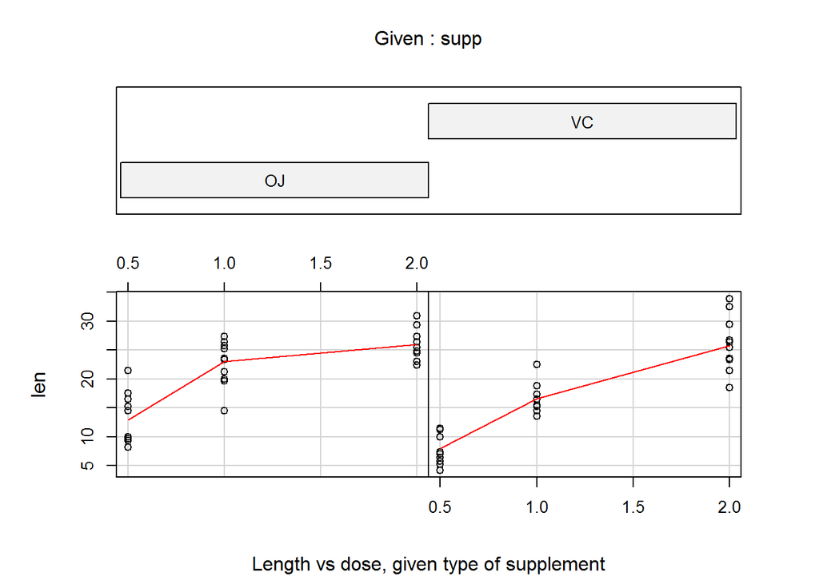

```r
require("graphics")
coplot (len~dose |supp, data=ToothGrowth, panel=panel.smooth, xlab="Length vs dose, given type of supplement")
```

These plots show different responses for dose, given the type of supplement. Both cases show increasing tooth growth with increasing dosages. It appears the OJ may show increasing tooth growth over VC at the .5 and 1 doses.

#### Summarize Means,Standard Deviations, and Standard Errors

```r
library(plyr)
ddply(ToothGrowth, c("dose", "supp"), summarise,
               N    = length(len),
               mean = mean(len),
               sd   = sd(len),
               se   = sd / sqrt(N) )
```

```
##   dose supp  N  mean    sd     se
## 1  0.5   OJ 10 13.23 4.460 1.4103
## 2  0.5   VC 10  7.98 2.747 0.8686
## 3  1.0   OJ 10 22.70 3.911 1.2368
## 4  1.0   VC 10 16.77 2.515 0.7954
## 5  2.0   OJ 10 26.06 2.655 0.8396
## 6  2.0   VC 10 26.14 4.798 1.5172
```

### 3. Comparison of OJ and VC at each dosage

For each test Compare p-values using the Bonferroni Correction. Since there are 3 tests we will compare to .05/3 (.0167).

.5 dose

```r
t.5 <- t.test(len ~ supp, paired = FALSE, var.equal = FALSE, data = ToothGrowth[ToothGrowth[,3]==.5,])
t.5
```

```
##
##  Welch Two Sample t-test
##
## data:  len by supp
## t = 3.17, df = 14.97, p-value = 0.006359
## alternative hypothesis: true difference in means is not equal to 0
## 95 percent confidence interval:
##  1.719 8.781
## sample estimates:
## mean in group OJ mean in group VC
##            13.23             7.98
```

p-value at .5 is 0.0064, confidence interal is 1.7191, 8.7809

1.0 dose

```r
t1.0 <- t.test(len ~ supp, paired = FALSE, var.equal = FALSE, data = ToothGrowth[ToothGrowth[,3]==1.0,])
```

p-value at 1.0 is 0.001, confidence interal is 2.8021, 9.0579

2.0 dose

```r
t2.0 <- t.test(len ~ supp, paired = FALSE, var.equal = FALSE, data = ToothGrowth[ToothGrowth[,3]==2.0,])
```

p-value at 2.0 is 0.9639, confidence interal is -3.7981, 3.6381

We see for the first two cases that the p-value is less than .0167 and the condfidence intervals do not contain zero. For these cases OJ gives more tooth growth than VC.

However there is little difference for the 2.0 dose

### 4. Now compare the effect of different doses for each supplement

We will compare .5 to 1 and 1 to 2 for each supplement.

Again we will correct for multiple test. .05/4 = .0125

```r
use<-subset(ToothGrowth, ToothGrowth$dose!=2.0 & ToothGrowth$supp=="VC")
tVC.51 <- t.test(len ~ dose, paired = FALSE, var.equal = FALSE, data = use)
tVC.51
```

```
##
##  Welch Two Sample t-test
##
## data:  len by dose
## t = -7.463, df = 17.86, p-value = 6.811e-07
## alternative hypothesis: true difference in means is not equal to 0
## 95 percent confidence interval:
##  -11.266  -6.314
## sample estimates:
## mean in group 0.5   mean in group 1
##              7.98             16.77
```

For VC is .5 dose different from 1 dose p-value at 1.0 is 6.811 × 10<sup>-7</sup>, confidence interal is -11.2657, -6.3143

```r
use<-subset(ToothGrowth, ToothGrowth$dose!=.5 & ToothGrowth$supp=="VC")
tVC12 <- t.test(len ~ dose, paired = FALSE, var.equal = FALSE, data = use)
tVC12
```

```
##
##  Welch Two Sample t-test
##
## data:  len by dose
## t = -5.47, df = 13.6, p-value = 9.156e-05
## alternative hypothesis: true difference in means is not equal to 0
## 95 percent confidence interval:
##  -13.054  -5.686
## sample estimates:
## mean in group 1 mean in group 2
##           16.77           26.14
```

For VC is 1.0 dose different from 2.0 dose? p-value at 1.0 is 9.1556 × 10<sup>-5</sup>, confidence interal is -13.0543, -5.6857

```r
use<-subset(ToothGrowth, ToothGrowth$dose!=2.0 & ToothGrowth$supp=="OJ")
tOJ.51 <- t.test(len ~ dose, paired = FALSE, var.equal = FALSE, data = use)
tOJ.51
```

```
##
##  Welch Two Sample t-test
##
## data:  len by dose
## t = -5.049, df = 17.7, p-value = 8.785e-05
## alternative hypothesis: true difference in means is not equal to 0
## 95 percent confidence interval:
##  -13.416  -5.524
## sample estimates:
## mean in group 0.5   mean in group 1
##             13.23             22.70
```

For OJ is .5 dose different from 1.0 dose? p-value at 1.0 is 8.7849 × 10<sup>-5</sup>, confidence interal is -13.4156, -5.5244

```r
use<-subset(ToothGrowth, ToothGrowth$dose!=.5 & ToothGrowth$supp=="OJ")
tOJ12 <- t.test(len ~ dose, paired = FALSE, var.equal = FALSE, data = use)
tOJ12
```

```
##
##  Welch Two Sample t-test
##
## data:  len by dose
## t = -2.248, df = 15.84, p-value = 0.0392
## alternative hypothesis: true difference in means is not equal to 0
## 95 percent confidence interval:
##  -6.5314 -0.1886
## sample estimates:
## mean in group 1 mean in group 2
##           22.70           26.06
```

For OJ is 1.0 dose different from 2.0 dose? p-value at 1.0 is 0.0392, confidence interal is -6.5314, -0.1886

Before applying the Bonferroni Correction, ee see that for both VC and OJ, the 1.0 dose gives significantly longer tooth growth than the .5 dose and the the 2.0 dose also gives signifcantly more growth than the 1.0 dose. This implies that all three doses are different from each other, and that length increases with dose.

However when we correct for multiple comparisons (4 tests divides the cutoff p by 4 to .0125), we no longer can conclude that the difference between the 1.0 and 2.0 dose is significant for the OJ, as the pvalue is 0.0392.

### 5. Testing overall assumptions

We are assuming that the samples are independent and normally distributed and representative of other guinea pigs , but we are not assuming equal variance between the groups.

The plots below show the assumption of normal distribution seesm reasonable for each dose/supplement combination.

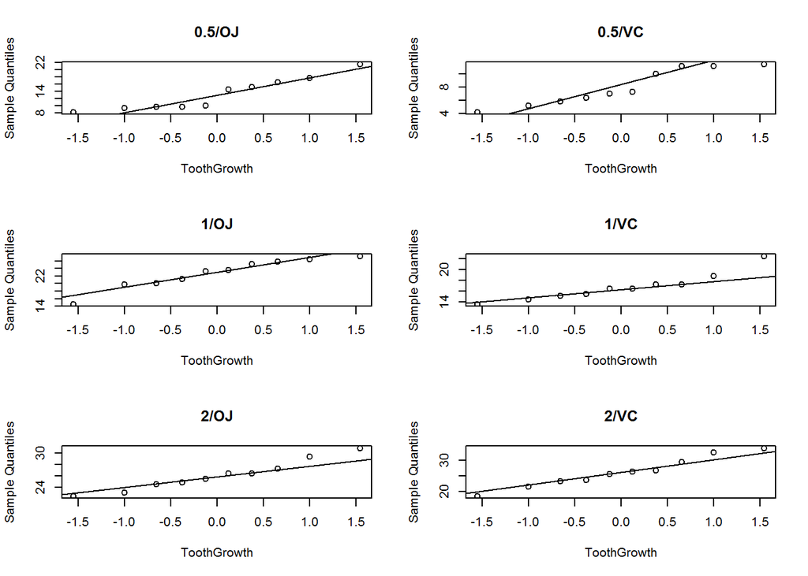

```r
ldose <- levels(factor(ToothGrowth$dose))
lsupp <- levels(ToothGrowth$supp)

par(mfrow=c(length(ldose),length(lsupp)))

for(i in ldose){
  for(j in lsupp){
    tmp <- with(ToothGrowth, len[dose==i & supp==j])
    qqnorm(tmp,xlab="ToothGrowth",
           main=paste(i,j,sep="/"))
    qqline(tmp)
  }
}
```